# Clear, reproducible and robust R code

2020-05-22

## Workshop overview

### Motivation

- reproducibility
- transparency
- good coding practice

### What will you learn?

- clear project structure
- good programming practice
  - unit testing
  - CI with github Actions
- holepunch
- code on github. https://github.com/selinaZitrone/YoMos2020

## Clear project structure

- follow the conventions of your research community / lab
- clear separation of data, method and output
- specify the computational environment
- adapt R package stucture for your research compendia

### Advantages

- benefit from quality control mechanisms needed to build your R package (`R CMD check`)
- writing functions is less error prone
- functions can be easily documented

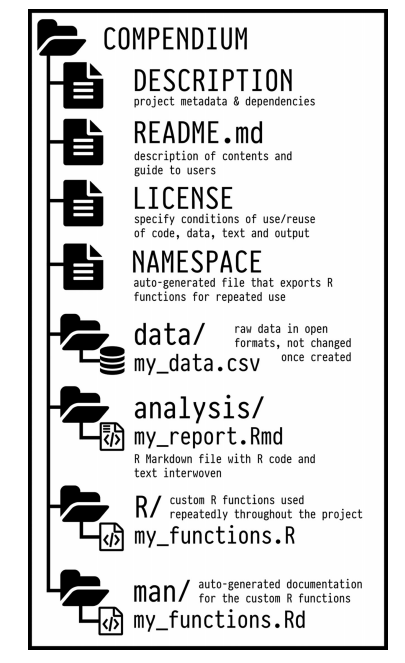

Mavick et al. 2018

- other packages generating empty project directory structures:
  - ProjectTemplate
  - prodigenr
  - workflowr

## Unit testing

- test individual units of source code to see if it is fit for use

### Why?

- Fewer bugs
- Better code structure
- Easier to pick up where you left
- Robust code
- You can rerun your tests at anytime to make sure you did not break anything

### How?

- Test external interfaces of functions
- One test for each behaviour
- Test fragile, complicated code
- Write a test if you find a but
- Test-first philosophy: write the test first, then write the code to pass it
- in R: `testthat` package (Hadley Wickham)

## Continous integration (CI)

> “If it hurts, do it more often” (Martin Fowler)

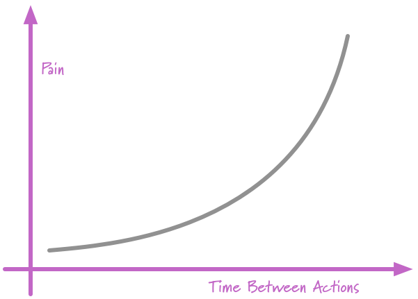

### Idea

- shared code repository (e.g. on github)
- integrate code frequently (every day) to the shared
- automated builds and tests after each commit
- code is only accepted if it builds and passes the test
- everyone can see the results of the lates commit

### Why?

- smaller changes are easier to handle
- get quick and frequent feedback
- early bug detection
- constant availability of current code version
- if you have to revert the codebase due to bugs you won’t lose that much
- However, can be time consuming and might be overkill for small or solo projects

## Github Actions for CI

- supports mac-OS, windows, linux, docker containers
- integration with github, so no seperate setup and authentification
- free for open source, academic or educational repos
- 20 concurrent jobs (40 with pro), 6 h per job, 72 h per workflow
- self host to remove the per job limit
- very easy to setup with R using the `usethis` package

## Reproducibility and Accessaiblity

[Holepunch](https://karthik.github.io/holepunch/)

## Resources

### Project structures

### Unit testing

- [Intro to unit testing in R](https://katherinemwood.github.io/post/testthat/)
- Testing with [`testthat`](http://r-pkgs.had.co.nz/tests.html)

### CI with github actions

- Jim Hester on [GitHub Actions with R](https://rstudio.com/resources/rstudioconf-2020/azure-pipelines-and-github-actions/)
- [Getting started](https://help.github.com/en/actions/getting-started-with-github-actions) with GitHub Actions
- [Examples](https://github.com/r-lib/actions) for Actions with R